# Quantile-Quantile Plots

Some example QQ plots

Author

Affiliation

Jon Yearsley

School of Biology and Environmental Science, UCD

Published

May, 2026

# Introduction

To help you identify different types of distributions from a quantile-quantile plot, we give examples of histograms and quantile-quantile plots for five qualitatively different distributions:

- A normal distribution
- A right-skewed distribution
- A left-skewed distribution
- An under-dispersed distribution
- An over-dispersed distribution

# Normally distributed data

Below is an example of data (150 observations) that are drawn from a normal distribution. The normal distribution is **symmetric**, so it has no skew (the mean is equal to the median).

On a Q-Q plot normally distributed data appears as roughly a straight line (although the ends of the Q-Q plot often start to deviate from the straight line).

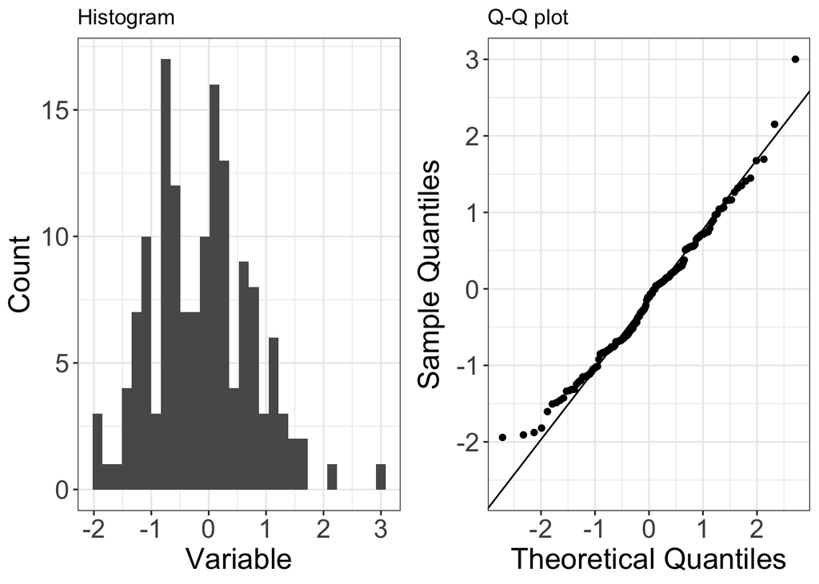

# Right-skewed data

Below is an example of data (150 observations) that are drawn from a distribution that is **right-skewed** (in this case it is the exponential distribution). Right-skew is also known as **positive skew**.

You can start to understand this pattern by considering the smallest and largest observations (left-hand and right-hand sides of the QQ-plot, respectively):

- the smallest observations are larger than you would expect from a normal distribution (i.e. the points are above the line on the QQ-plot). This means the lower tail of the data’s distribution has been **reduced**, relative to a normal distribution.
- the largest observations are larger than you would expect from a normal distribution (i.e. the points are above the line on the QQ-plot). This means the upper tail of the data’s distribution has been **extended**, relative to a normal distribution.

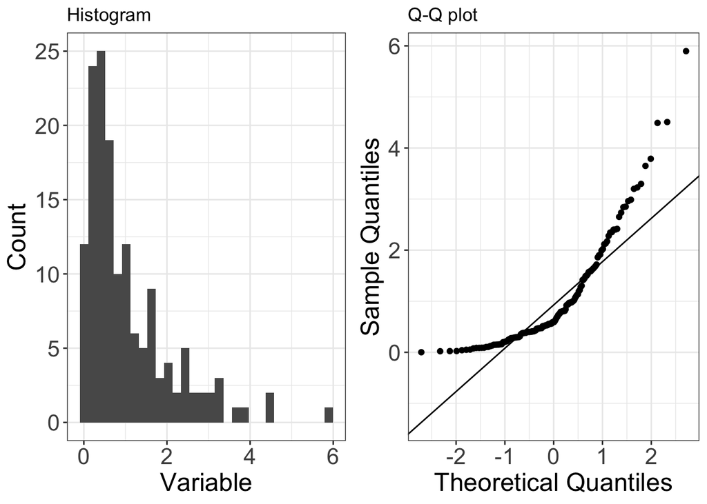

# Left-skewed data

Below is an example of data (150 observations) that are drawn from a distribution that is **left-skewed** (in this case it is a negative exponential distribution). Left-skew is also known as **negative skew**.

On a Q-Q plot left-skewed data appears as a concave curve (the opposite of right-skewed data).

You can start to understand this pattern by considering the smallest and largest observations (left-hand and right-hand sides of the QQ-plot, respectively):

- the smallest observations are smaller than you would expect from a normal distribution (i.e. the points are below the line on the QQ-plot). This means the lower tail of the data’s distribution has been **extended**, relative to a normal distribution.
- the largest observations are smaller than you would expect from a normal distribution (i.e. the points are below the line on the QQ-plot). This means the upper tail of the data’s distribution has been **reduced**, relative to a normal distribution.

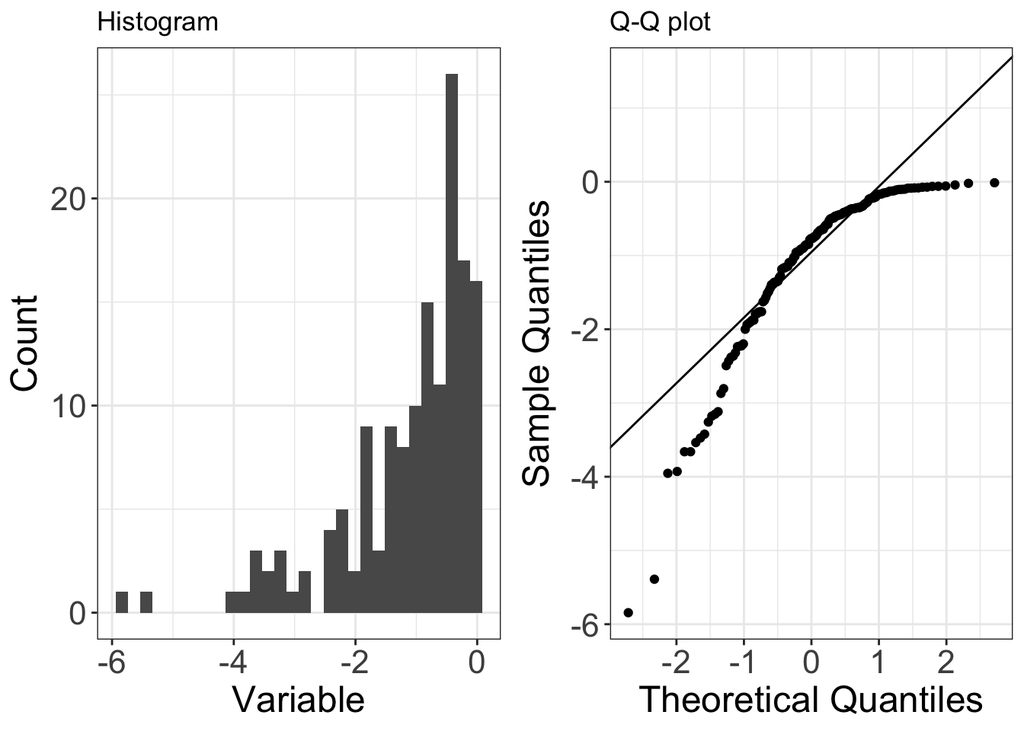

# Under-dispersed data

Below is an example of data (150 observations) that are drawn from a distribution that is **under-dispersed** relative to a normal distribution (in this case it is the uniform distribution). Under-dispersed data has a reduced number of outliers (i.e. the distribution has thinner tails than a normal distribution). Under-dispersed data is also known as having a **platykurtic distribution** and as having **negative excess kurtosis**.

On a Q-Q plot under-dispersed data appears S shaped.

You can start to understand this pattern by considering the smallest and largest observations (left-hand and right-hand sides of the QQ-plot, respectively):

- the smallest observations are larger than you would expect from a normal distribution (i.e. the points are above the line on the QQ-plot). This means the lower tail of the data’s distribution has been **reduced**, relative to a normal distribution.
- the largest observations are less than you would expect from a normal distribution (i.e. the points are below the line on the QQ-plot). This means the upper tail of the data’s distribution has been **reduced**, relative to a normal distribution.

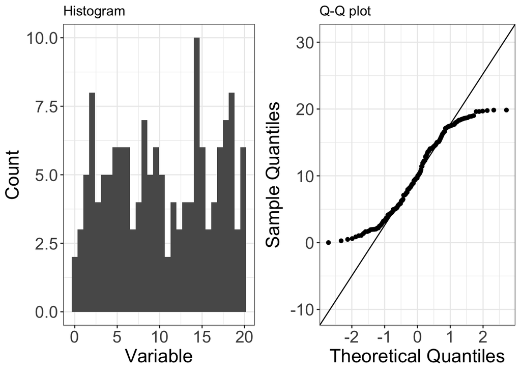

# Over-dispersed data

Below is an example of data (150 observations) that are drawn from a distribution that is **over-dispersed** relative to a normal distribution (in this case it is a Laplace distribution). Over-dispersed data has an increased number of outliers (i.e. the distribution has fatter tails than a normal distribution). Over-dispersed data is also known as having a **leptokurtic distribution** and as having **positive excess kurtosis**.

On a Q-Q plot over-dispersed data appears as a flipped S shape (the opposite of under-dispersed data).

You can start to understand this pattern by considering the smallest and largest observations (left-hand and right-hand sides of the QQ-plot, respectively):

- the smallest observations are smaller than you would expect from a normal distribution (i.e. the points are below the line on the QQ-plot). This means the lower tail of the data’s distribution has been **extended**, relative to a normal distribution.
- the largest observations are larger than you would expect from a normal distribution (i.e. the points are above the line on the QQ-plot). This means the upper tail of the data’s distribution has been **extended**, relative to a normal distribution.

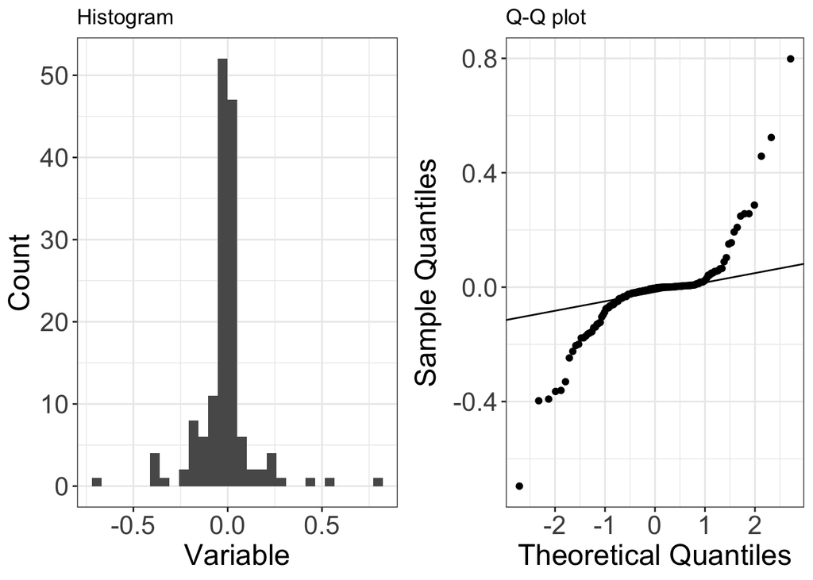